# Problem Set 2

Author

Amber Geiger

Published

10/14/2026

[output not shown]

## Data

Our data series consists of monthly unemployment rates for the whole United States, as well as the states of Oregon, California, Texas, and New York. It came directly from FRED, or the Federal Reserve Economic Data database, starting from January 1st, 1976 to October, 2025.

```r
library(tidyverse)
library(knitr)
unemp_raw <- read_rds("data/unemp_raw.rds")

head(unemp_raw)
```

```
# A tibble: 6 × 3
  symbol date       price
  <chr>  <date>     <dbl>
1 UNRATE 1976-01-01   7.9
2 UNRATE 1976-02-01   7.7
3 UNRATE 1976-03-01   7.6
4 UNRATE 1976-04-01   7.7
5 UNRATE 1976-05-01   7.4
6 UNRATE 1976-06-01   7.6
```

## Wrangling

```r
library(knitr)
```

Note: Installed the knitr package to use the kable() function. Used digits = 2 for rounding precision and presentation.

```r
unemp <- unemp_raw |>
  rename(unemployment_rate = price) |>
  mutate(
    region = case_when(
      symbol == "UNRATE" ~ "United States",
      symbol == "ORUR" ~ "Oregon",
      symbol == "CAUR" ~ "California",
      symbol == "TXUR" ~ "Texas",
      symbol == "NYUR" ~ "New York"
    )
  ) |>
  arrange(region, date) |>
  group_by(region) |>
  mutate(
    unemployment_rate = replace(
      unemployment_rate,
      date == as.Date("2025-10-01"),
      unemployment_rate[date == as.Date("2025-09-01")]
    ),
    unemployment_rate_change =
      unemployment_rate - lag(unemployment_rate)
  ) |>
  ungroup()

unemp_summary <- unemp |>
  group_by(region) |>
  summarize(
    mean_rate = mean(unemployment_rate, na.rm = TRUE),
    min_rate = min(unemployment_rate, na.rm = TRUE),
    max_rate = max(unemployment_rate, na.rm = TRUE)
  )

unemp_recent <- unemp |>
  filter(date >= as.Date("2015-01-01"))

unemp_recent_summary <- unemp_recent |>
  group_by(region) |>
  summarize(
    mean_rate = mean(unemployment_rate, na.rm = TRUE),
    min_rate = min(unemployment_rate, na.rm = TRUE),
    max_rate = max(unemployment_rate, na.rm = TRUE)
  )
```

Note: Did this to avoid the mentioned FRED data issues as advised in announcement.

### Table 1: Full Unemployment Data

Table 1 gives us the mean, minimum, and maximum unemployment rates for each region (US, Oregon, California, Texas, and New York) across the full data period, meaning from January 1976 to October 2025.

```r
kable(unemp_summary, digits = 2)
```

| region | mean_rate | min_rate | max_rate |
| --- | --- | --- | --- |
| California | 7.07 | 3.8 | 16.1 |
| New York | 6.35 | 3.8 | 16.7 |
| Oregon | 6.66 | 3.4 | 13.7 |
| Texas | 5.85 | 3.4 | 12.8 |
| United States | 6.05 | 3.4 | 14.8 |

### Table 2: Unemployment Date January 2015 and Onward

Table 2 was filtered to give us the mean, minimum, and maximum unemployment rates for each region (US, Oregon, California, Texas, and New York) from January 2015 onward.

```r
kable(unemp_recent_summary, digits = 2)
```

| region | mean_rate | min_rate | max_rate |
| --- | --- | --- | --- |
| California | 5.63 | 3.8 | 16.1 |
| New York | 5.10 | 3.8 | 16.7 |
| Oregon | 4.75 | 3.4 | 13.7 |
| Texas | 4.58 | 3.4 | 12.8 |
| United States | 4.62 | 3.4 | 14.8 |

### Table 3: Largest Monthly Increases in Unemployment

```r
unemp_top_increases_no_covid <- unemp |>
  filter(format(date, "%Y") != "2020") |>
  slice_max(
    order_by = unemployment_rate_change,
    n = 5,
    with_ties = TRUE
  )

kable(unemp_top_increases_no_covid, digits = 2)
```

| symbol | date | unemployment_rate | region | unemployment_rate_change |
| --- | --- | --- | --- | --- |
| TXUR | 2009-05-01 | 7.6 | Texas | 1.1 |
| ORUR | 2008-12-01 | 8.9 | Oregon | 0.7 |
| ORUR | 2008-11-01 | 8.2 | Oregon | 0.7 |
| ORUR | 2009-01-01 | 9.6 | Oregon | 0.7 |
| ORUR | 1980-03-01 | 7.4 | Oregon | 0.6 |
| UNRATE | 1980-04-01 | 6.9 | United States | 0.6 |

### Table 4: Largest Monthly Decreases in Unemployment

```r
unemp_top_decreases_no_covid <- unemp |>
  filter(format(date, "%Y") != "2020") |>
  slice_min(
    order_by = unemployment_rate_change,
    n = 5,
    with_ties = TRUE
  )

kable(unemp_top_decreases_no_covid, digits = 2)
```

| symbol | date | unemployment_rate | region | unemployment_rate_change |
| --- | --- | --- | --- | --- |
| UNRATE | 1983-07-01 | 9.4 | United States | -0.7 |
| NYUR | 2021-09-01 | 6.2 | New York | -0.6 |
| ORUR | 1977-05-01 | 7.8 | Oregon | -0.5 |
| CAUR | 2021-07-01 | 7.4 | California | -0.5 |
| CAUR | 2021-09-01 | 6.5 | California | -0.5 |
| NYUR | 2021-07-01 | 7.0 | New York | -0.5 |
| UNRATE | 2010-12-01 | 9.3 | United States | -0.5 |
| UNRATE | 2014-04-01 | 6.2 | United States | -0.5 |
| UNRATE | 2021-07-01 | 5.4 | United States | -0.5 |

## Visualization

### Plot 1: Unemployment Rates Overtime (Full Data)

Plot 1 compares the monthly unemployment rates across each region (US, Oregon, California, Texas, and New York) across the entire data period, meaning from January 1976 to October 2025. Different colors represent a different region, e.g. red for California, showing trends in the unemployment rates overtime.

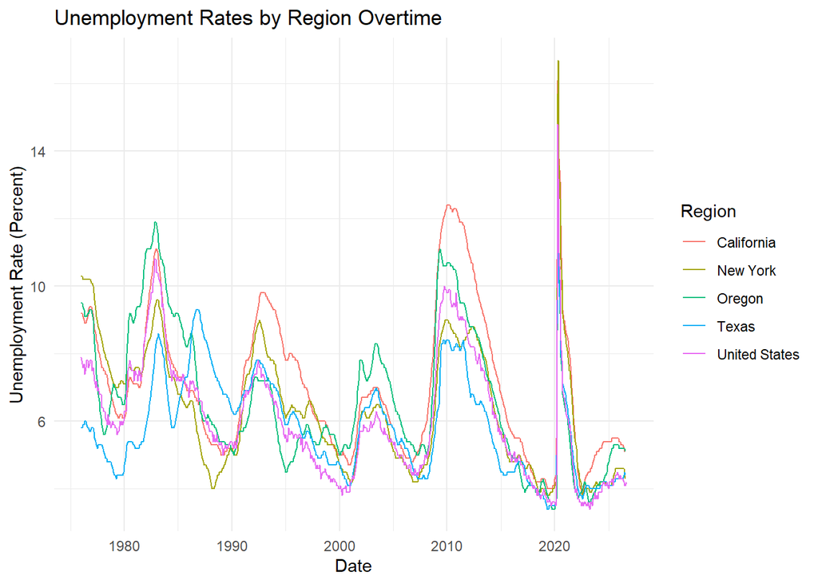

```r
ggplot(unemp, aes(x = date, y = unemployment_rate, color = region)) +
  geom_line() +
  labs(
    title = "Unemployment Rates by Region Overtime",
    x = "Date",
    y = "Unemployment Rate (Percent)",
    color = "Region"
  ) +
  theme_minimal()
```

### Plot 2: Unemployment Rates by Region

Plot 2 still compares the monthly unemployment rates across each region (US, Oregon, California, Texas, and New York) across the entire data period, meaning from January 1976 to October 2025. However, it uses different panels to illustrate each region’s trends, rather than an overlapping view seen in Plot 1.

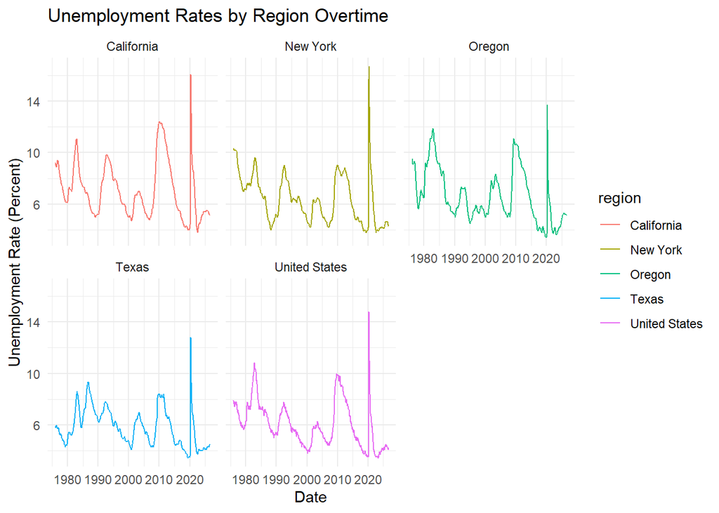

```r
ggplot(unemp, aes(x = date, y = unemployment_rate, color = region)) +
  geom_line() +
  facet_wrap(~ region) +
  labs(
    title = "Unemployment Rates by Region Overtime",
    x = "Date",
    y = "Unemployment Rate (Percent)"
  ) +
  theme_minimal()
```

### Plot 3: The Mean Unemployment Rates by Region

Plot 3 still compares the monthly unemployment rates across each region (US, Oregon, California, Texas, and New York) across the entire data period, meaning from January 1976 to October 2025. However, it utilizes a bar chart instead of a line graph, ordered by the mean values of each region’s unemployment rates.

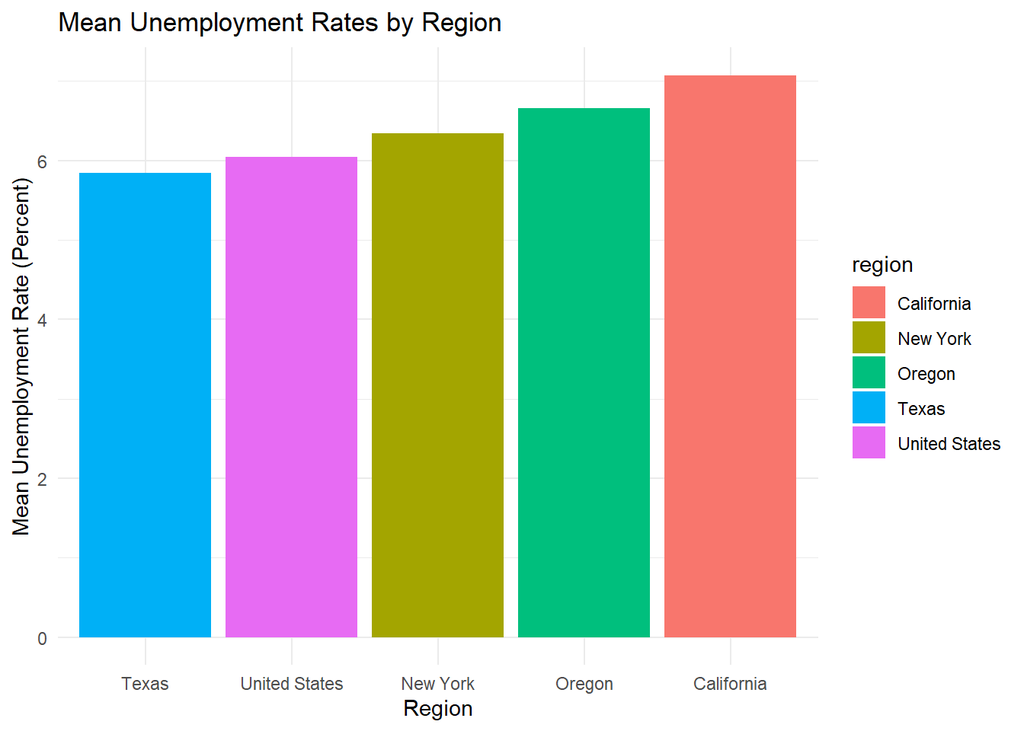

```r
ggplot(
  unemp_summary,
  aes(
    x = fct_reorder(region, mean_rate),
    y = mean_rate,
    fill = region
  )
) +
  geom_col() +
  labs(
    title = "Mean Unemployment Rates by Region",
    x = "Region",
    y = "Mean Unemployment Rate (Percent)"
  ) +
  theme_minimal()
```

### Plot 4: Great Recession vs Covid Pandemic

Plot 4 compares the monthly unemployment rates across each region (US, Oregon, California, Texas, and New York) during the Great Recession defined as between 2007-2010, and the Covid Pandemic, defined as 2019-2022. The reason I choose to explore these two periods was because I was curious how they compare in unemployment rates given their differing elements and origins. A financial crisis vs global pandemic are differing shocks but both have devastating consequences.

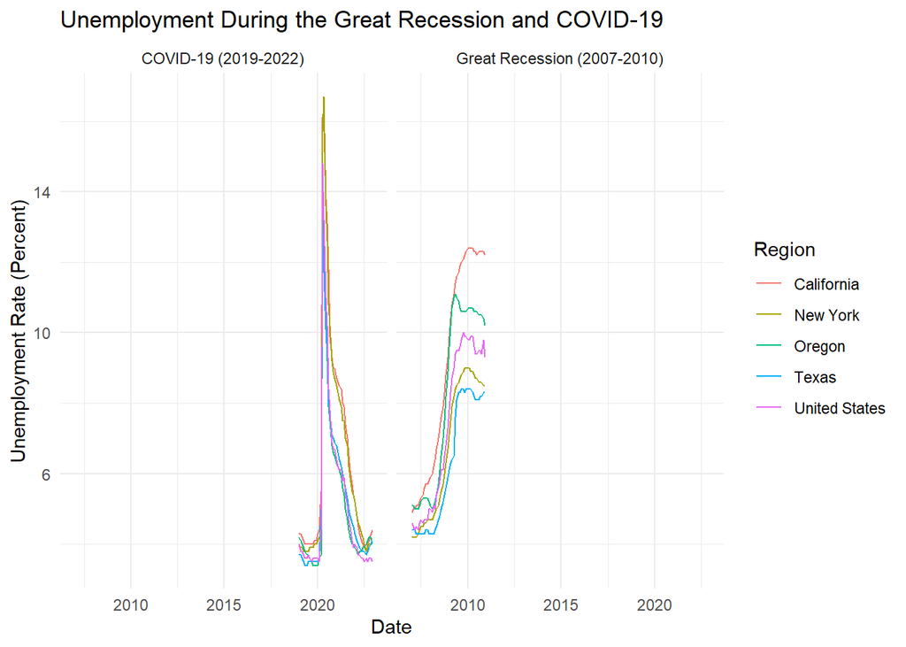

```r
unemp_recessions <- unemp |>
  filter(
    (date >= as.Date("2007-01-01") &
       date <= as.Date("2010-12-01")) |
      (date >= as.Date("2019-01-01") &
         date <= as.Date("2022-12-01"))
  ) |>
  mutate(
    period = if_else(
      date < as.Date("2011-01-01"),
      "Great Recession (2007-2010)",
      "COVID-19 (2019-2022)"
    )
  )

ggplot(
  unemp_recessions,
  aes(x = date, y = unemployment_rate, color = region)
) +
  geom_line() +
  facet_wrap(~ period) +
  labs(
    title = "Unemployment During the Great Recession and COVID-19",
    x = "Date",
    y = "Unemployment Rate (Percent)",
    color = "Region"
  ) +
  theme_minimal()
```

## Reflection

In past R Studio Classes, I often did my problem sets all in the Quarto document, not starting with an original script. This process helped me with understanding organization and cleanliness within my code, especially though really taking the time to separate directory, script, writeup, and utilize console vs terminal. Code seems easier to track, cleaner, and makes more sense when I look it over! It was intuitive once I started to get to the table making and plotting, as it was about getting the general format down and assessing the different command needed based on what you want to show. My biggest struggles have always been file organization and proper set up, so I’m glad this problem set helped me identify strategies to combat that, but I also need to build up my own confidence.

Note on AI Use: As allowed in class, I used AI as a coding assistant when I got stuck (mainly with the FRED data –> to Quarto document), and to double check my proper saving tecqniques and git push. I can testify that I took the time to understand what I coded and what each thing in this document does. Thank you.